# INTRODUCTION

## My Objective:

What countries or regions rank the highest in overall happiness and each of the six factors contributing to happiness? How did country ranks or scores change between 2016 and 2019 reports?

# 1.Data processing with pandas( report 2016)

**1.1 Loading data:**

```python
import pandas as pd
import matplotlib.pyplot as plt
```

```python
#loading file
path16="C://Users//SS//Desktop//World Happiness Report//Data//"
file_name16="2016.csv"
df16=pd.read_csv(path16+file_name16,sep=',')
df16
```

|  | Country | Region | Happiness Rank | Happiness Score | Lower Confidence Interval | Upper Confidence Interval | Economy (GDP per Capita) | Family | Health (Life Expectancy) | Freedom | Trust (Government Corruption) | Generosity | Dystopia Residual |
| --- | --- | --- | --- | --- | --- | --- | --- | --- | --- | --- | --- | --- | --- |
| 0 | Denmark | Western Europe | 1 | 7.526 | 7.460 | 7.592 | 1.44178 | 1.16374 | 0.79504 | 0.57941 | 0.44453 | 0.36171 | 2.73939 |
| 1 | Switzerland | Western Europe | 2 | 7.509 | 7.428 | 7.590 | 1.52733 | 1.14524 | 0.86303 | 0.58557 | 0.41203 | 0.28083 | 2.69463 |
| 2 | Iceland | Western Europe | 3 | 7.501 | 7.333 | 7.669 | 1.42666 | 1.18326 | 0.86733 | 0.56624 | 0.14975 | 0.47678 | 2.83137 |
| 3 | Norway | Western Europe | 4 | 7.498 | 7.421 | 7.575 | 1.57744 | 1.12690 | 0.79579 | 0.59609 | 0.35776 | 0.37895 | 2.66465 |
| 4 | Finland | Western Europe | 5 | 7.413 | 7.351 | 7.475 | 1.40598 | 1.13464 | 0.81091 | 0.57104 | 0.41004 | 0.25492 | 2.82596 |
| ... | ... | ... | ... | ... | ... | ... | ... | ... | ... | ... | ... | ... | ... |
| 152 | Benin | Sub-Saharan Africa | 153 | 3.484 | 3.404 | 3.564 | 0.39499 | 0.10419 | 0.21028 | 0.39747 | 0.06681 | 0.20180 | 2.10812 |
| 153 | Afghanistan | Southern Asia | 154 | 3.360 | 3.288 | 3.432 | 0.38227 | 0.11037 | 0.17344 | 0.16430 | 0.07112 | 0.31268 | 2.14558 |
| 154 | Togo | Sub-Saharan Africa | 155 | 3.303 | 3.192 | 3.414 | 0.28123 | 0.00000 | 0.24811 | 0.34678 | 0.11587 | 0.17517 | 2.13540 |
| 155 | Syria | Middle East and Northern Africa | 156 | 3.069 | 2.936 | 3.202 | 0.74719 | 0.14866 | 0.62994 | 0.06912 | 0.17233 | 0.48397 | 0.81789 |
| 156 | Burundi | Sub-Saharan Africa | 157 | 2.905 | 2.732 | 3.078 | 0.06831 | 0.23442 | 0.15747 | 0.04320 | 0.09419 | 0.20290 | 2.10404 |

157 rows × 13 columns

**1.2 Data exploration:**

```python
#The data type of each column
df16.dtypes
```

```
Country                           object
Region                            object
Happiness Rank                     int64
Happiness Score                  float64
Lower Confidence Interval        float64
Upper Confidence Interval        float64
Economy (GDP per Capita)         float64
Family                           float64
Health (Life Expectancy)         float64
Freedom                          float64
Trust (Government Corruption)    float64
Generosity                       float64
Dystopia Residual                float64
dtype: object
```

```python
#Generate descriptive statistics
df16.describe()
```

|  | Happiness Rank | Happiness Score | Lower Confidence Interval | Upper Confidence Interval | Economy (GDP per Capita) | Family | Health (Life Expectancy) | Freedom | Trust (Government Corruption) | Generosity | Dystopia Residual |
| --- | --- | --- | --- | --- | --- | --- | --- | --- | --- | --- | --- |
| count | 157.000000 | 157.000000 | 157.000000 | 157.000000 | 157.000000 | 157.000000 | 157.000000 | 157.000000 | 157.000000 | 157.000000 | 157.000000 |
| mean | 78.980892 | 5.382185 | 5.282395 | 5.481975 | 0.953880 | 0.793621 | 0.557619 | 0.370994 | 0.137624 | 0.242635 | 2.325807 |
| std | 45.466030 | 1.141674 | 1.148043 | 1.136493 | 0.412595 | 0.266706 | 0.229349 | 0.145507 | 0.111038 | 0.133756 | 0.542220 |
| min | 1.000000 | 2.905000 | 2.732000 | 3.078000 | 0.000000 | 0.000000 | 0.000000 | 0.000000 | 0.000000 | 0.000000 | 0.817890 |
| 25% | 40.000000 | 4.404000 | 4.327000 | 4.465000 | 0.670240 | 0.641840 | 0.382910 | 0.257480 | 0.061260 | 0.154570 | 2.031710 |
| 50% | 79.000000 | 5.314000 | 5.237000 | 5.419000 | 1.027800 | 0.841420 | 0.596590 | 0.397470 | 0.105470 | 0.222450 | 2.290740 |
| 75% | 118.000000 | 6.269000 | 6.154000 | 6.434000 | 1.279640 | 1.021520 | 0.729930 | 0.484530 | 0.175540 | 0.311850 | 2.664650 |
| max | 157.000000 | 7.526000 | 7.460000 | 7.669000 | 1.824270 | 1.183260 | 0.952770 | 0.608480 | 0.505210 | 0.819710 | 3.837720 |

**1.3 Cleaning and preparation:**

```python
#Detect missing values
df16.isna().sum()
```

```
Country                          0
Region                           0
Happiness Rank                   0
Happiness Score                  0
Lower Confidence Interval        0
Upper Confidence Interval        0
Economy (GDP per Capita)         0
Family                           0
Health (Life Expectancy)         0
Freedom                          0
Trust (Government Corruption)    0
Generosity                       0
Dystopia Residual                0
dtype: int64
```

```python
#Detect missing values
df16.isnull().sum()
```

```
Country                          0
Region                           0
Happiness Rank                   0
Happiness Score                  0
Lower Confidence Interval        0
Upper Confidence Interval        0
Economy (GDP per Capita)         0
Family                           0
Health (Life Expectancy)         0
Freedom                          0
Trust (Government Corruption)    0
Generosity                       0
Dystopia Residual                0
dtype: int64
```

**1.4 Analsyse**

*1.4.1 How many counties are there in the report?*

```python
len(df16['Country'])
```

```
157
```

*1.4.2 The number of countries each region*

```python
df16.groupby('Region').count()['Country']
```

```
Region
Australia and New Zealand           2
Central and Eastern Europe         29
Eastern Asia                        6
Latin America and Caribbean        24
Middle East and Northern Africa    19
North America                       2
Southeastern Asia                   9
Southern Asia                       7
Sub-Saharan Africa                 38
Western Europe                     21
Name: Country, dtype: int64
```

*1.4.3 Top 10 countries which have highest happiness score?*

```python
df16_1=df16.sort_values('Happiness Rank',ascending=True)[:10][['Country','Region','Happiness Rank']]
df16_1
```

|  | Country | Region | Happiness Rank |
| --- | --- | --- | --- |
| 0 | Denmark | Western Europe | 1 |
| 1 | Switzerland | Western Europe | 2 |
| 2 | Iceland | Western Europe | 3 |
| 3 | Norway | Western Europe | 4 |
| 4 | Finland | Western Europe | 5 |
| 5 | Canada | North America | 6 |
| 6 | Netherlands | Western Europe | 7 |
| 7 | New Zealand | Australia and New Zealand | 8 |
| 8 | Australia | Australia and New Zealand | 9 |
| 9 | Sweden | Western Europe | 10 |

*1.4.4 Which region has the most countries in top 10?*

```python
df16_2=df16_1.groupby('Region').count().iloc[:,:1]
df16_2
```

| Region | Country |
| --- | --- |
| Australia and New Zealand | 2 |
| North America | 1 |
| Western Europe | 7 |

*1.4.5 Chart 1: The number of countries by region in top 10*

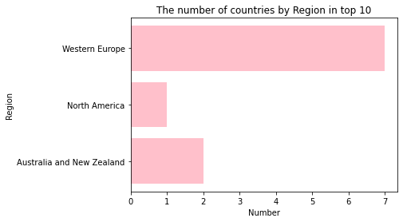

```python
Num_country=list(df16_2['Country'])
Region=['Australia and New Zealand','North America','Western Europe']
fig,ax=plt.subplots()
chart_1=ax.barh(Region,Num_country, align='center',color='pink')
ax.set_xlabel('Number')
ax.set_ylabel('Region')
ax.set_title('The number of countries by Region in top 10')
```

*1.4.6 Chart 2: The mean score of 6 factors*

[figure not shown]

```python
six_factors=list(df16.head(0).iloc[:,6:12])# six factors affect happiness score
df16_4=df16[six_factors].mean()
df16_5=pd.DataFrame(df16_4,columns=['Mean_Score'],index=None)
df16_4.index
#make data
x=['GDP','Family','Health','Freedom','Trust Gov','Geneosity']
y=df16_5['Mean_Score']
fig, ax = plt.subplots()
Chart2=ax.bar(x, y,width=0.5, edgecolor="white", linewidth=0.7)
ax.set_xlabel('Factor')
ax.set_ylabel('Score')
ax.set_title('Mean score of 6 factors')
plt.show()
```